# Example 6

Thomas Klebel

9 5 2020

# Task desc

An analysis was carried out to investigate the differences of the alcohol concentration in wines. For this purpose the following features were measured for 500 wines: tartaric of wine WEINSAEU (in g=dm3), acetic acid ESSAEU (in g=dm3), citric acid ZTROSAEU (in g=dm3), residual sugar RESTZUCKER (in g=dm3), chloride CHLORIDE (in g=dm3), specific gravity DICHTE (in g=cm3), PH, SULFAT (in g=dm3), ALCOHOL (in Vol%), SORT (Type 1, 2, 3, 4). The data are found in “WeinAlk.csv”.

Carry out a regression analysis to explain ALCOHOL using the independent variables DICHTE, RESTZUCKER, SORT, CHLORIDE, WEINSAEU und PH durch!

```r
library(tidyverse)
library(patchwork)
theme_set(theme_bw())
alc <- read_csv("data/WeinAlk.csv", locale = locale(decimal_mark = ",")) %>%
  mutate(SORTE = as.factor(SORTE))
```

```r
mod1 <- lm(ALKOHOL ~ DICHTE + RESTZUCKER + SORTE + CHLORIDE + WEINSAEU + PH,
           data = alc)
```

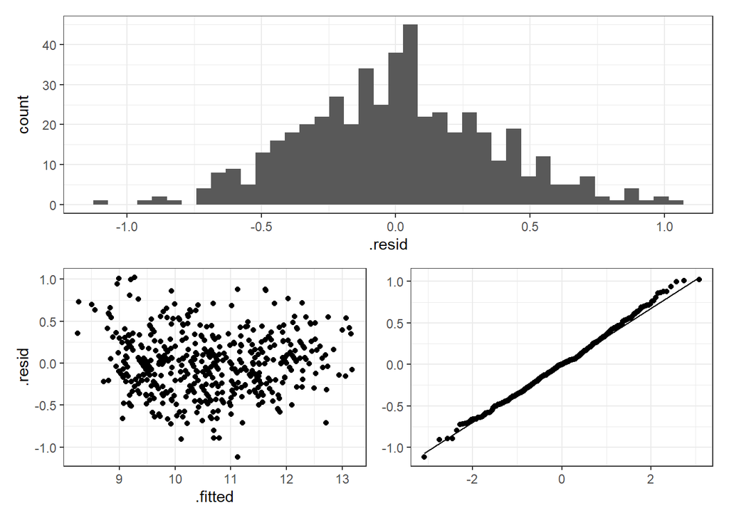

```r
plot_diag <- function(df) {
  p1 <- ggplot(df, aes(.resid)) +
    geom_histogram(bins = 40)


  p2 <- ggplot(df, aes(.fitted, .resid)) +
    geom_point()

  p3 <- ggplot(df, aes(sample = .resid)) +
    geom_qq_line() +
    geom_qq() +
    labs(x = NULL, y = NULL)

  p1 / (p2 + p3)
}

broom::augment(mod1) %>%
  plot_diag()
```

# (a) Determine the coefficients of DICHTE and RESTZUCKER?

```r
summary(mod1)
```

```
##
## Call:
## lm(formula = ALKOHOL ~ DICHTE + RESTZUCKER + SORTE + CHLORIDE +
##     WEINSAEU + PH, data = alc)
##
## Residuals:
##      Min       1Q   Median       3Q      Max
## -1.11969 -0.24301  0.00034  0.22121  1.02272
##
## Coefficients:
##               Estimate Std. Error t value Pr(>|t|)
## (Intercept)  6.696e+02  1.456e+01  45.989  < 2e-16 ***
## DICHTE      -6.754e+02  1.497e+01 -45.109  < 2e-16 ***
## RESTZUCKER   2.247e-01  7.515e-03  29.896  < 2e-16 ***
## SORTE2       1.454e-01  4.863e-02   2.991  0.00293 **
## SORTE3       1.938e-01  5.115e-02   3.790  0.00017 ***
## SORTE4       2.793e-01  5.833e-02   4.788 2.24e-06 ***
## CHLORIDE    -5.192e-02  8.145e-01  -0.064  0.94920
## WEINSAEU     5.107e-01  2.511e-02  20.334  < 2e-16 ***
## PH           2.233e+00  1.386e-01  16.108  < 2e-16 ***
## ---
## Signif. codes:  0 '***' 0.001 '**' 0.01 '*' 0.05 '.' 0.1 ' ' 1
##
## Residual standard error: 0.3597 on 481 degrees of freedom
## Multiple R-squared:  0.9015, Adjusted R-squared:  0.8999
## F-statistic: 550.2 on 8 and 481 DF,  p-value: < 2.2e-16
```

- Dichte: -675.4049997
- Restzucker: 0.2246795

```r
car::vif(mod1)
```

```
##                GVIF Df GVIF^(1/(2*Df))
## DICHTE     5.659765  1        2.379026
## RESTZUCKER 4.462728  1        2.112517
## SORTE      1.479550  3        1.067468
## CHLORIDE   1.235992  1        1.111752
## WEINSAEU   1.863719  1        1.365181
## PH         1.756098  1        1.325178
```

```r
alc %>%
  summarise(cor = cor(DICHTE, RESTZUCKER),
            mean_dichte = mean(DICHTE),
            sd_dichte = sd(DICHTE),
            min_dichte = min(DICHTE),
            max_dichte = max(DICHTE))
```

```
## # A tibble: 1 x 5
##     cor mean_dichte sd_dichte min_dichte max_dichte
##   <dbl>       <dbl>     <dbl>      <dbl>      <dbl>
## 1 0.798       0.994   0.00258      0.987       1.00
```

# (b) Estiamte ALCOHOL for a wine of SORT = 2 with specific gravity DICHTE = 0.999, RESTZUCKER = 5.6; CHLORIDE = 0.041; PH = 3.21 and WEINSAEU = 6.7?

```r
tibble(WEINSAEU = 6.7,
       RESTZUCKER = 5.6,
       CHLORIDE = .041,
       DICHTE = .999,
       PH = 3.21,
       SORTE = "2") %>%
  predict(mod1, newdata = .)
```

```
##        1
## 6.906647
```

# (c) Find R2 and the variance of the error term?

```r
summary(mod1)$r.squared
```

```
## [1] 0.9014943
```

```r
# variance of error
summary(mod1)$sigma^2
```

```
## [1] 0.1293496
```

# (d) By how much does ALCOHOL change from SORT = 2 to SORT = 3, if all other parameters remain the same?

Differenz ist nicht statistisch signifikant!

```r
alc2 <- alc %>%
  mutate(SORTE = relevel(SORTE, "2"))
mod2 <- update(mod1, data = alc2)
coef(mod2)[["SORTE3"]]
```

```
## [1] 0.04840442
```

```r
summary(mod2)
```

```
##
## Call:
## lm(formula = ALKOHOL ~ DICHTE + RESTZUCKER + SORTE + CHLORIDE +
##     WEINSAEU + PH, data = alc2)
##
## Residuals:
##      Min       1Q   Median       3Q      Max
## -1.11969 -0.24301  0.00034  0.22121  1.02272
##
## Coefficients:
##               Estimate Std. Error t value Pr(>|t|)
## (Intercept)  6.698e+02  1.455e+01  46.020  < 2e-16 ***
## DICHTE      -6.754e+02  1.497e+01 -45.109  < 2e-16 ***
## RESTZUCKER   2.247e-01  7.515e-03  29.896  < 2e-16 ***
## SORTE1      -1.454e-01  4.863e-02  -2.991  0.00293 **
## SORTE3       4.840e-02  4.460e-02   1.085  0.27833
## SORTE4       1.339e-01  5.120e-02   2.615  0.00920 **
## CHLORIDE    -5.192e-02  8.145e-01  -0.064  0.94920
## WEINSAEU     5.107e-01  2.511e-02  20.334  < 2e-16 ***
## PH           2.233e+00  1.386e-01  16.108  < 2e-16 ***
## ---
## Signif. codes:  0 '***' 0.001 '**' 0.01 '*' 0.05 '.' 0.1 ' ' 1
##
## Residual standard error: 0.3597 on 481 degrees of freedom
## Multiple R-squared:  0.9015, Adjusted R-squared:  0.8999
## F-statistic: 550.2 on 8 and 481 DF,  p-value: < 2.2e-16
```